# PHA Exit Demographics

Public Health - Seattle & King County

9/2/2021

**Data are preliminary and not for distribution.**

The data below show demographics of people who exited from King County Housing Authority or Seattle Housing Authority between 2012 and 2020. Note the following limitations:

- KCHA data is incomplete for exits prior to late 2015.
- Only complete exits are included here. People with action type = 6 who had subsequent 50058 records are not considered to have exited.
- Exit types are categorized according to the document here: https://github.com/PHSKC-APDE/hud_hears/blob/main/data_processing/PHA_exit_definitions.csv.

# Individual-level analyses

## Exits over time

### Proportion of people exiting

- Approximately 5% of KCHA and SHA residents exit in a given year, excluding 2020 when the COVID pandemic reduced this proportion.

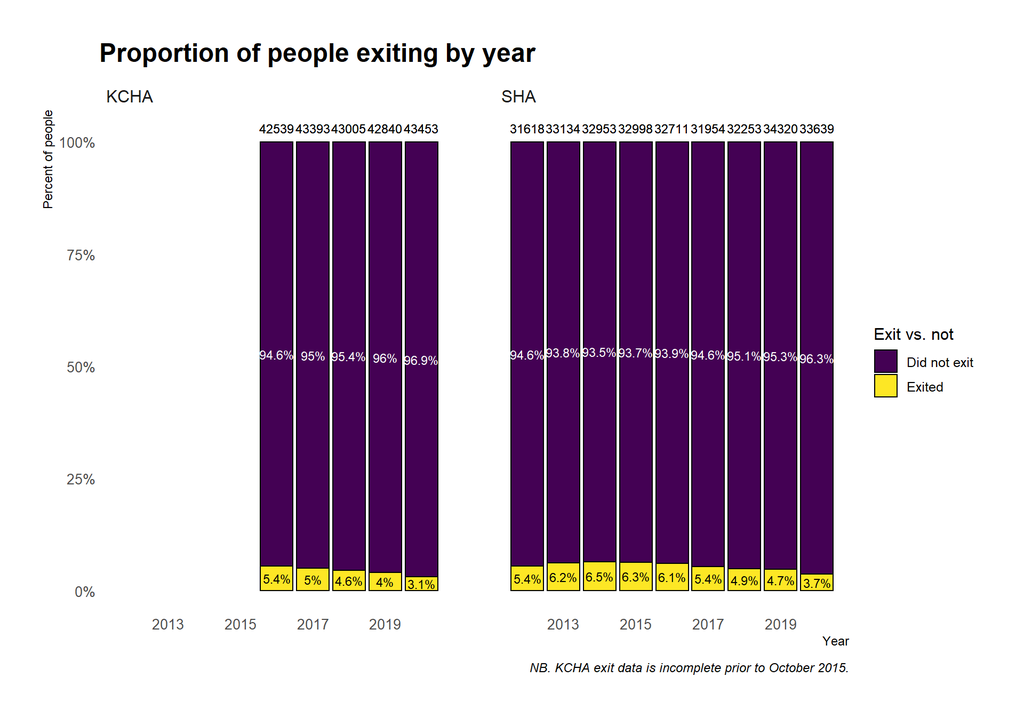

### Type of exits by year

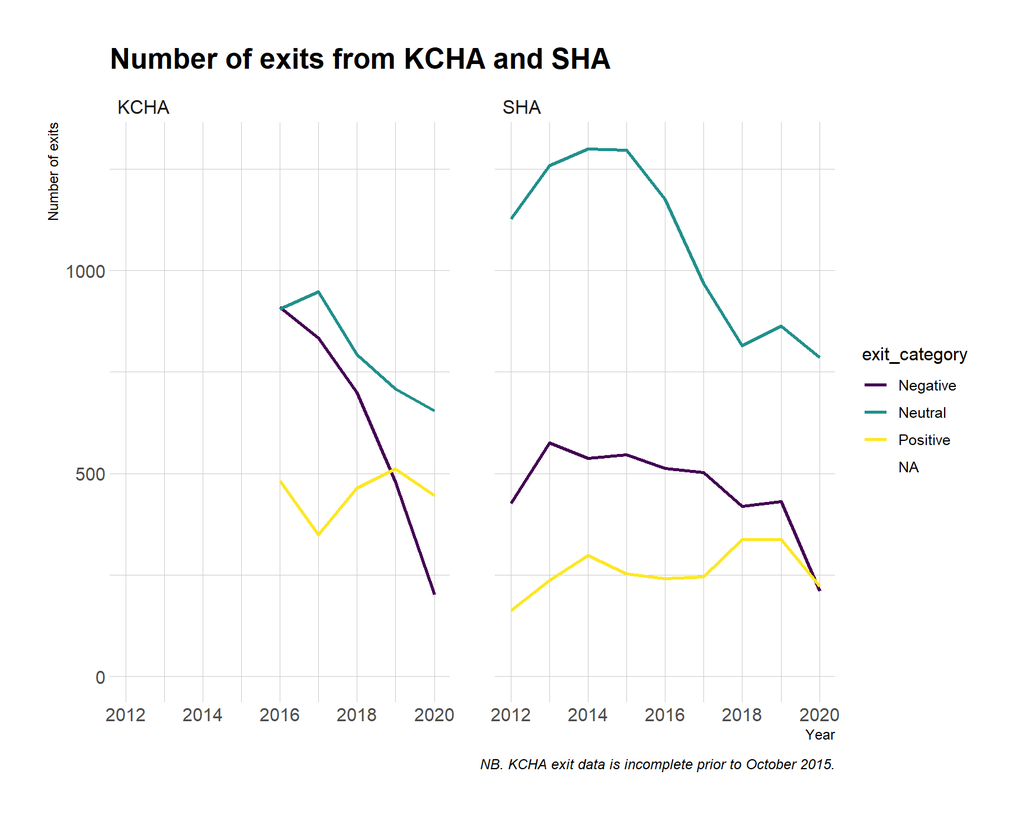

- The proportion of KCHA exits due to positive reasons increased over time, peaking at 34.2% in 2020.
- Negative exits decreased as a proportion of all KCHA exits from 2016 to 2020.
- The proportion of SHA exits for positive reasons was flat between 2012 and 2017, but increased to 21.5% in 2018.
- The proportion of all SHA exits that were negative was largely unchanged over time.

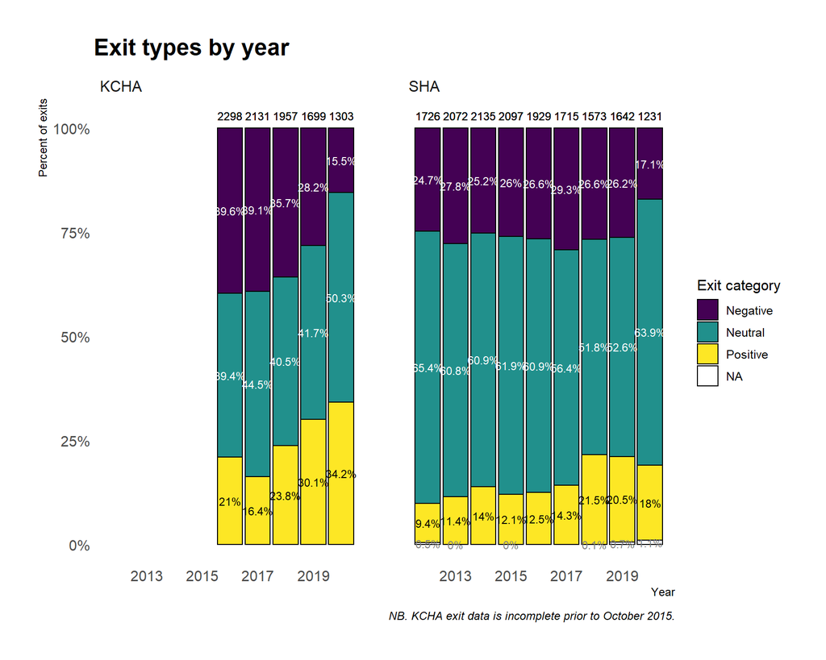

## Exits by demographics

### Exits by age

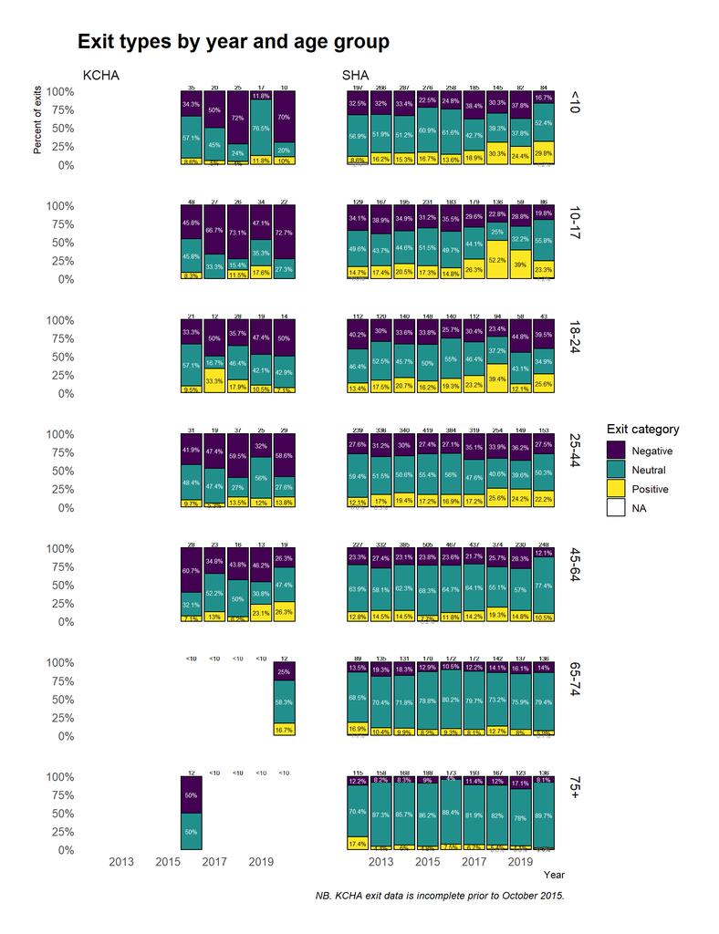

### Exits by gender

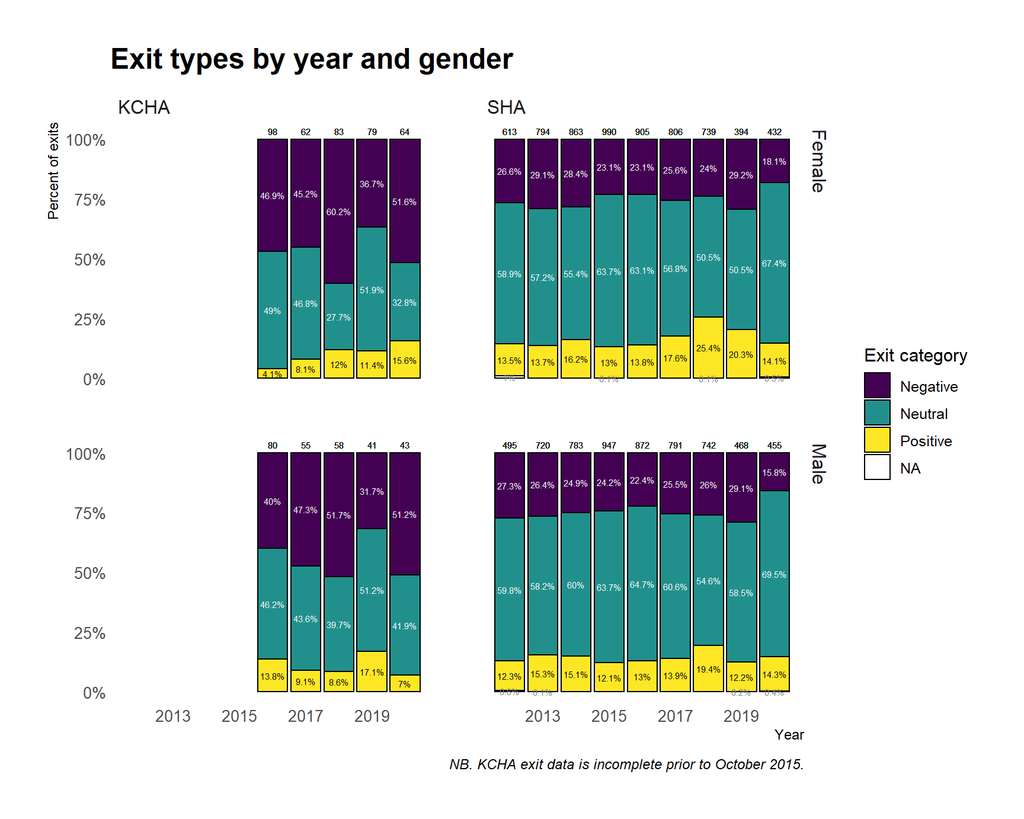

### Exits by race/ethnicity

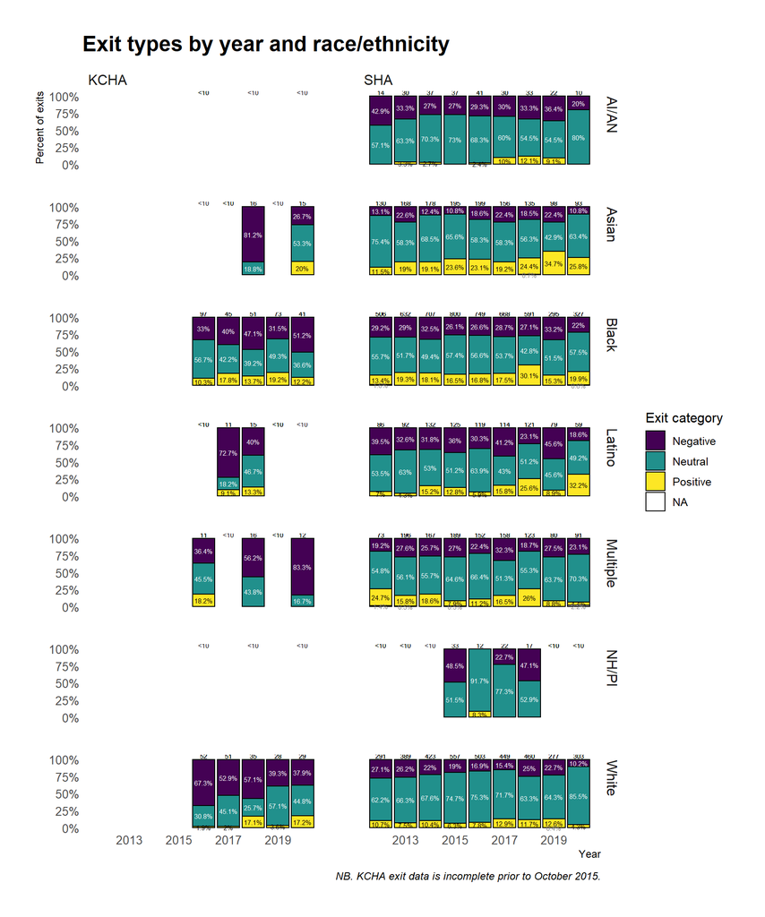

### Exits by time in housing

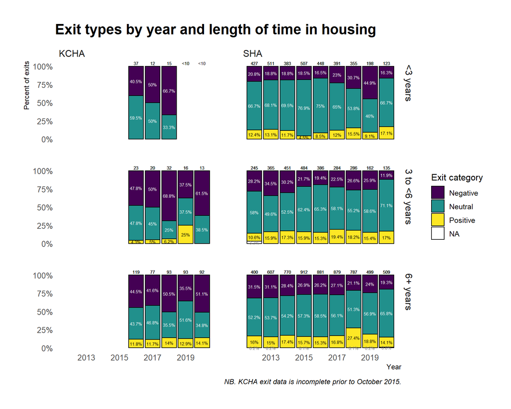

### Exits by program type

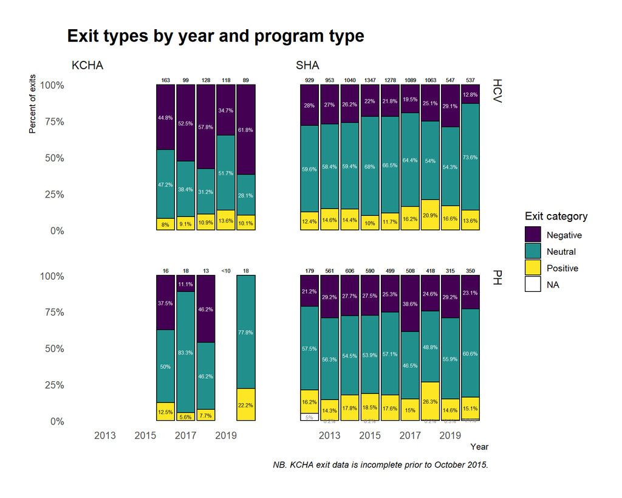

### Exits by portfolio

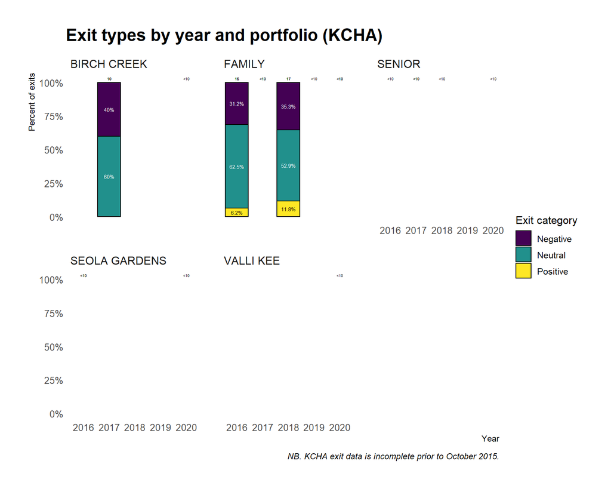

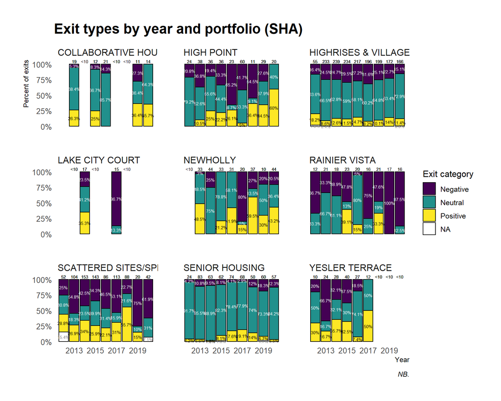